# Approximate Bayesian Computation

# Simple SIR model for comparison

For this session, let’s use a simpler SIR model to make the concepts clearer:

```julia
"""
Simple SIR model for pedagogical purposes.
"""
function simulate_sir(θ, init_state, times)
    R_0, D_inf = θ[:R_0], θ[:D_inf]

    function sir_ode!(du, u, p, t)
        S, I, R = u
        β, γ = p
        N = S + I + R

        du[1] = -β * S * I / N
        du[2] = β * S * I / N - γ * I
        du[3] = γ * I
    end

    β = R_0 / D_inf
    γ = 1.0 / D_inf
    u0 = [init_state[:S], init_state[:I], init_state[:R]]
    prob = ODEProblem(sir_ode!, u0, (times[1], times[end]), [β, γ])
    sol = solve(prob, Tsit5(), saveat=times)

    # Extract incidence (new infections per day)
    S_values = sol[1, :]
    incidence = [0.0; -diff(S_values)]

    return DataFrame(time=times, S=S_values,
                     I=sol[2, :],
                     R=sol[3, :],
                     Inc=incidence)
end
```

```
Main.Notebook.simulate_sir
```

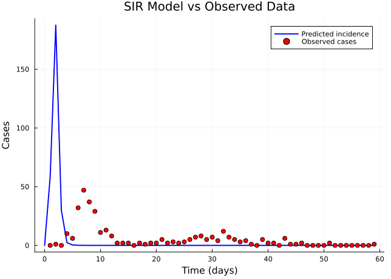

```julia
# Try some parameters
## `times` starts at 0.0, the left edge of the first observation day, because the
## incidence over that day is S(0) - S(1) and there is no way to form it without a
## point at 0. `traj.Inc[i + 1]` is then the incidence over the day the i-th
## observation counts
times = [0.0; flu_tdc.time]
θ_test = Dict(:R_0 => 10.0, :D_inf => 2.5)
## The island as the ship lands, at the start of day 1. Of the five islanders it
## brought back, three had been ill during the eight day voyage and are past their
## infectious period, so they start recovered; the two who fell ill on landing
## start infectious. N = 284, the island population
init_test = Dict(:S => 279.0, :I => 2.0, :R => 3.0)

traj_test = simulate_sir(θ_test, init_test, times)

# Plot
plot(traj_test.time, traj_test.Inc,
     label="Predicted incidence", linewidth=2, color=:blue)
scatter!(flu_tdc.time, flu_tdc.obs,
         label="Observed cases", markersize=4, color=:red,
         xlabel="Time (days)", ylabel="Cases",
         title="SIR Model vs Observed Data")
```

Not a perfect fit, but good enough for illustration!

In your own work, you should run prior and posterior predictive checks when fitting models. We skip them here to focus on observation model choices.

**NoteYesterday’s likelihood fit, refitted**

Later we compare the ABC posterior against a likelihood-based one. That is the Poisson fit from the observation models session, rerun here so this session stands on its own.

```julia
@model function sir_poisson(times, init_state, n_obs)
    R_0 ~ Uniform(1.0, 20.0)
    D_inf ~ Uniform(1.0, 10.0)
    ρ ~ Uniform(0.1, 1.0)

    traj = simulate_sir(Dict(:R_0 => R_0, :D_inf => D_inf), init_state, times)

    lambdas = [max(ρ * traj.Inc[i + 1], 1e-10) for i in 1:n_obs]
    obs ~ arraydist(Poisson.(lambdas))

    return traj
end

model_poisson = sir_poisson(times, init_test, length(flu_tdc.obs)) | (; obs = flu_tdc.obs)
chain_poisson = sample(model_poisson, NUTS(0.65), 500, progress=false)
```

```
┌ Info: Found initial step size
└   ϵ = 0.2
```

```
╭─FlexiChain (500 iterations, 1 chain) ────────────────────────────────────────╮
│ ↓ iter  = 251:750                                                            │
│ → chain = 1:1                                                                │
│                                                                              │
│ Parameters (3) ── AbstractPPL.VarName                                        │
│  Float64  R_0, D_inf, ρ                                                      │
│                                                                              │
│ Extras (14)                                                                  │
│  Int64    n_steps, tree_depth                                                │
│  Bool     is_accept, numerical_error                                         │
│  Float64  acceptance_rate, log_density, hamiltonian_energy,                  │
│           hamiltonian_energy_error, max_hamiltonian_energy_error, step_size, │
│           nom_step_size, logprior, loglikelihood, logjoint                   │
╰──────────────────────────────────────────────────────────────────────────────╯
```

# Approximate Bayesian Computation

## ABC: Making the distance explicit

Instead of choosing a parametric likelihood, ABC directly chooses:

1. *Summary statistics*: What features of the data matter?
2. *Distance metric*: How do we measure similarity?
3. *Threshold*: How close is “close enough”?

Here is a simple ABC rejection sampler from scratch:

```julia
"""
Simple ABC rejection sampler.
Samples from prior, simulates data, accepts if distance < threshold.
"""
function abc_rejection(prior_sampler, simulator, distance_fn, observed_data,
                      threshold, n_samples)
    samples = []
    n_attempts = 0
    max_attempts = n_samples * 1000  # Give up after many attempts

    while length(samples) < n_samples && n_attempts < max_attempts
        n_attempts += 1

        # Sample from prior
        θ = prior_sampler()

        # Simulate data
        simulated_data = simulator(θ)

        # Compute distance
        d = distance_fn(simulated_data, observed_data)

        # Accept if close enough
        if d < threshold
            push!(samples, θ)
        end
    end

    acceptance_rate = length(samples) / n_attempts
    println("Acceptance rate: $(round(acceptance_rate * 100, digits=2))%")
    println("Attempts needed: $n_attempts")

    ## The attempt count is returned as well as printed, so the comparison at the
    ## end of the session can put it beside the ABC-SMC simulation count
    return samples, n_attempts
end
```

```
Main.Notebook.abc_rejection
```

Now let’s define the components:

```julia
# Prior sampler
function sample_from_prior()
    R_0 = rand(Uniform(1.0, 20.0))
    D_inf = rand(Uniform(1.0, 10.0))
    ρ = rand(Uniform(0.1, 1.0))
    return [R_0, D_inf, ρ]
end

# Simulator
function simulate_sir_abc(params)
    R_0, D_inf, ρ = params
    θ = Dict(:R_0 => R_0, :D_inf => D_inf)
    traj = simulate_sir(θ, init_test, times)
    return ρ .* traj.Inc[2:end]  ## drop the padding zero at t = 0, to match the observations
end

# Distance functions
distance_L1(sim, obs) = sum(abs.(sim .- obs))

function distance_L2(sim, obs)
    return sqrt(sum((sim .- obs).^2))
end

function distance_weighted(sim, obs)
    # Weight by 1/observation (similar to Poisson variance structure)
    weights = 1.0 ./ (obs .+ 1.0)
    return sum(weights .* abs.(sim .- obs))
end

# Observed data
observed_data = flu_tdc.obs
```

```
59-element Vector{Int64}:
  0
  1
  0
 10
  6
 32
 47
 37
 29
 11
  ⋮
  2
  0
  0
  0
  0
  0
  0
  0
  1
```

**NoteUnderstanding the distance functions**

We’ve defined three distance functions, each with different properties:

- **L1 (Manhattan)**: `sum(|sim - obs|)` - Sums absolute deviations. Robust to outliers because large errors contribute linearly. A mismatch of 20 cases counts twice as much as a mismatch of 10.
- **L2 (Euclidean)**: `sqrt(sum((sim - obs)²))` - Root of squared deviations. Penalises large errors more heavily than L1. A mismatch of 20 cases counts *four times* as much as 10 (because 20² = 400 vs 10² = 100).
- **Weighted**: `sum(w × |sim - obs|)` where `w = 1/(obs + 1)` - Weights inversely by observation size. This mimics Poisson variance scaling: a mismatch of 5 when obs=2 is penalised more than when obs=50. Useful when you care about relative rather than absolute fit.

**When to use each:**

- L1: Good default. Robust to occasional large mismatches.
- L2: When large deviations are particularly bad (e.g., outbreak peaks).
- Weighted: When fit quality should be scale-independent (similar to Poisson likelihood).

Run ABC with L1 distance:

**TipChoosing the threshold**

ABC rejection sampling is sensitive to the threshold choice:

- **Too strict** (e.g., 100): below the closest this model can get, so it accepts nothing at all and exhausts the attempt budget
- **Too loose** (e.g., 1000): Fast, but approximate posterior is close to the prior
- **In between** (e.g., 200-400): Runs quickly, but at the loose end of this band the posterior still carries a good deal of the prior

We start with a relaxed threshold (300) here. Note what that costs: the run below accepts around a quarter of what it proposes, which by the guidance later in this session is loose enough that the posterior is still carrying a good deal of the prior. The exercise that follows asks you to tighten it.

**If you get 0 samples**: Increase the threshold (try 400, then 500). The sampler may be struggling to find parameter combinations that produce simulations close to the data. This can happen due to random variation - ABC is inherently stochastic.

```julia
# Start with a relaxed threshold to get some samples
threshold = 300.0  # Relaxed for faster acceptance

println("Running ABC rejection sampler...")
abc_samples, abc_attempts = abc_rejection(
    sample_from_prior,
    simulate_sir_abc,
    distance_L1,
    observed_data,
    threshold,
    200  # Target number of samples
)

println("\nObtained $(length(abc_samples)) samples")
```

```
Running ABC rejection sampler...
Acceptance rate: 26.18%
Attempts needed: 764

Obtained 200 samples
```

**TipExercise: Find a workable threshold**

The threshold above (300) was chosen for you. Find out what it is doing by changing it.

1. Re-run the sampler with a stricter threshold, say 200. How many simulations does it get through, and how long does it take?
2. Re-run with a loose one, say 800. How wide is the resulting posterior for $R_0$ compared with the run at 300?
3. What is the trade-off you are making, and how would you decide on a value if you had no answer to compare against?

**TipSolution**

Tightening the threshold narrows the posterior but the acceptance rate collapses, so you wait much longer for the same number of samples: at 200 about 2% of prior draws are accepted against about a quarter at 300, so the same 200 samples cost roughly ten times as many simulations. There is a floor as well. The closest this SIR gets to these data anywhere in the prior box is a distance of about 165, so a threshold below that accepts nothing however long you leave it running.

Loosening it accepts almost everything, so the sampler is fast but the posterior drifts back towards the prior: you are no longer conditioning on the data very much.

There is no way to pick $\epsilon$ from first principles. In practice you lower it until either the posterior stops changing or the acceptance rate becomes unaffordable, whichever comes first. This is exactly the weakness that ABC-SMC in the next section is designed to address, by walking the threshold down automatically.

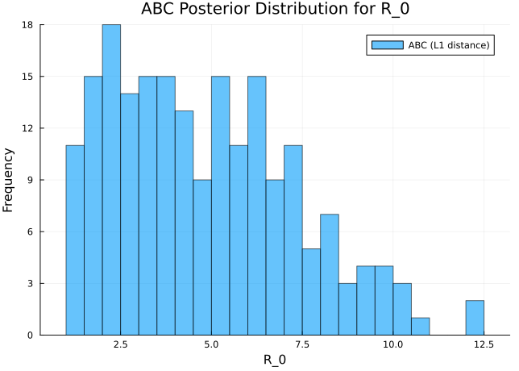

```julia
# Extract parameters
if length(abc_samples) > 0
    abc_df = DataFrame(
        R_0 = [s[1] for s in abc_samples],
        D_inf = [s[2] for s in abc_samples],
        ρ = [s[3] for s in abc_samples]
    )

    # Plot ABC results
    histogram(abc_df.R_0, bins=30, alpha=0.6,
              label="ABC (L1 distance)",
              xlabel="R_0", ylabel="Frequency",
              title="ABC Posterior Distribution for R_0")
else
    println("No samples accepted - threshold too strict!")
end
```

## Compare distance metrics

Different distance functions give different results.

**TipExercise: Predict before you run**

Before running the cell below, write down your answer to this: if one day’s count were much higher than the model predicts, which of the three distances — L1, L2 or the weighted distance — would react most strongly, and why?

Then run it and see whether the ordering matches what you expected.

**TipSolution**

L2 reacts most strongly, *provided the rest of the trajectory fits*. It squares the deviation, so a single day off by 30 contributes 900 while thirty days off by 1 contribute 30 between them. Squared distances are dominated by their worst point.

L1 adds the absolute deviations, so that same bad day contributes 30 and nothing more. It is the forgiving choice, and it is why L1 is a common default in ABC when you expect reporting glitches.

The caveat matters here more than usual, as the cell below shows. Our SIR model fits these data badly, and against a badly fitting simulation the L2 total is already dominated by the model’s systematic errors, so the injected outlier accounts for a *smaller* share of L2 than of L1. The rule of thumb describes a model that is otherwise doing well.

The weighted distance depends entirely on the weights. If it upweights the peak and the outlier falls near the peak, it can react more sharply than either; if the outlier falls somewhere it downweights, it can barely notice.

The connection worth carrying forward is that this is the same comparison as Poisson against negative binomial, which you met yesterday. A Poisson likelihood behaves like L2 in that one improbable day dominates the total; a negative binomial behaves more like L1. Choosing a distance and choosing an observation model are the same decision about how much a single surprising observation should count.

The three distances are on different scales, so their raw values say nothing about sensitivity. Watch instead how much each one *moves* when a single day goes wrong.

```julia
# Take one simulation, disturb a single day of the data it is compared against,
# and ask how much of each distance that one day is then responsible for
test_params = [10.0, 2.5, 0.8]
test_sim = simulate_sir_abc(test_params)

spiked = copy(observed_data)
spiked[30] += 30  # one day, thirty extra cases

# Per-day contributions to each distance, before summing
l1_terms(sim, obs) = abs.(sim .- obs)
l2_terms(sim, obs) = (sim .- obs) .^ 2
weighted_terms(sim, obs) = abs.(sim .- obs) ./ (obs .+ 1.0)

# The likelihood fit's posterior mean, taken from the chain rather than copied out
# of it. It is closer than the simulation above but still a poor fit, at a distance
# of about 308, which the threshold of 300 would reject
fitted_params = [mean(chain_poisson[:R_0]), mean(chain_poisson[:D_inf]),
                 mean(chain_poisson[:ρ])]
fitted_sim = simulate_sir_abc(fitted_params)

for (label, sim) in (("poorly fitting simulation", test_sim),
                     ("closer simulation", fitted_sim))
    println(label)
    for (name, terms) in (("L1", l1_terms), ("L2", l2_terms),
                          ("weighted", weighted_terms))
        t = terms(sim, spiked)
        println("  ", rpad(name, 9), " day 30 contributes ",
                round(100 * t[30] / sum(t), digits=1), "% of the summed terms")
    end
    ## And what the spike does to the distances the session actually uses, which
    ## take a root in the L2 case
    for (name, d) in (("L1", distance_L1), ("L2", distance_L2),
                      ("weighted", distance_weighted))
        before, after = d(sim, observed_data), d(sim, spiked)
        println("  ", rpad(name, 9), " distance moves ",
                round(100 * (after - before) / before, digits=1), "%")
    end
end
```

```
poorly fitting simulation
  L1        day 30 contributes 6.6% of the summed terms
  L2        day 30 contributes 4.2% of the summed terms
  weighted  day 30 contributes 0.5% of the summed terms
  L1        distance moves 5.7%
  L2        distance moves 2.1%
  weighted  distance moves 0.1%
closer simulation
  L1        day 30 contributes 10.4% of the summed terms
  L2        day 30 contributes 19.2% of the summed terms
  weighted  day 30 contributes 1.5% of the summed terms
  L1        distance moves 9.8%
  L2        distance moves 11.0%
  weighted  distance moves 0.5%
```

The ordering depends on how well the rest of the trajectory fits, which is worth more than the headline rule. Against the closer simulation, the spiked day accounts for about a fifth of the summed squares and about a tenth of the summed absolute errors, so squaring does concentrate attention on it. Look at the second block, though. `distance_L2` takes the square root of those summed squares, and once it does the two distances move by almost the same amount. That is not the root cancelling the squaring in general. It happens because neither simulation here is close to the data: the spike is small against a sum of squares the model’s own errors already dominate, so the root linearises the change. Give the same spike to a trajectory that does fit and the textbook behaviour comes back. The best fit available anywhere in the prior box moves L1 by 18% and L2 by 48%, and a near-perfect series moves them by 38% and 161%. Against the poorly fitting one the ordering reverses, because L2 is already saturated by the model’s own errors and one more large deviation barely registers among them.

An outlier is only conspicuous relative to how well everything else is explained.

Notice that choosing a distance metric in ABC is philosophically similar to choosing a parametric likelihood.

## ABC-SMC: Sequential Monte Carlo ABC

The rejection sampler above is inefficient - most samples from the prior are rejected, wasting computation. ABC-SMC (Sequential Monte Carlo ABC) attacks that by gradually tightening the acceptance threshold across multiple generations, reusing the particles that survived the previous one.

The key idea, introduced by [Toni et al. (2009)](https://doi.org/10.1098/rsif.2008.0172), is:

1. *Start permissive*: Begin with a loose threshold that accepts many samples
2. *Gradually tighten*: Reduce the threshold across generations
3. *Reuse good samples*: Instead of sampling from the prior each time, perturb samples that passed the previous threshold

The aim is to reach a threshold that rejection sampling could not afford, by refining particles that are already close rather than searching blindly from the prior each time. How much that saves depends entirely on the problem, the schedule and the kernel, so treat quoted speedup factors with suspicion until you have counted your own.

**NoteImplementation: ABC-SMC**

This is a simplified ABC-SMC for pedagogical purposes. It does compute the importance weights, which is what makes the sample valid, but production implementations (like ApproxBayes.jl or GpABC.jl) add adaptive thresholds and better perturbation kernels.

The redraw is worth a closer look. A perturbation landing outside the prior sends the loop back to its start, which draws a *new parent* as well as a new perturbation, so the proposal is the whole mixture restricted to the prior box. The constant that restriction introduces is the same for every particle, so it cancels when the weights are normalised, and the weights computed here are exact. Had the redraw kept the same parent and only re-perturbed, it would not cancel, and children of near-boundary particles would come out over-weighted.

**Note on `Threads.@threads`**: The code below uses `Threads.@threads` to parallelise the particle loop — this macro distributes iterations across available CPU threads, so each particle can be simulated concurrently. For this to have any effect, Julia must be started with multiple threads (e.g., `julia -t auto`). See the threading note in MCMC Diagnostics for setup instructions. Without multiple threads, the loop runs sequentially (slower but still correct).

```julia
# The prior appears twice: as bounds to sample from, and as a support check used
# when weighting. The importance weights below are a ratio of prior density to
# perturbation density, and because all three priors are uniform that numerator
# is a constant which cancels in the normalisation, so only the support matters.
const PRIOR_BOUNDS = [(1.0, 20.0), (1.0, 10.0), (0.1, 1.0)]

in_prior(θ) = all(lo <= θ[i] <= hi for (i, (lo, hi)) in enumerate(PRIOR_BOUNDS))

"Standard deviation of the perturbation kernel applied to a particle."
kernel_sd(θ) = 0.1 .* abs.(θ)

"Density of the perturbation kernel that moves `θ_from` to `θ_to`."
function kernel_pdf(θ_to, θ_from)
    sds = kernel_sd(θ_from)
    return prod(pdf(Normal(θ_from[d], sds[d]), θ_to[d]) for d in eachindex(θ_to))
end

"""
Simple ABC-SMC implementation.
Uses a sequence of decreasing thresholds, perturbing the particles that survived
the previous one. Returns the particles, their importance weights, the number of
simulations each generation cost, and the effective sample size of each
generation's weights.
"""
function abc_smc(prior_sampler, in_prior, simulator, distance_fn, observed_data,
                thresholds, n_particles; max_simulations_per_generation = 100_000)

    particles = Vector{Vector{Float64}}()
    weights = Float64[]
    sim_counts = Int[]
    ess_history = Float64[]

    for (t_idx, threshold) in enumerate(thresholds)
        println("\nGeneration $t_idx: threshold = $threshold")
        new_particles = Vector{Vector{Float64}}(undef, n_particles)
        simulations = Threads.Atomic{Int}(0)

        Threads.@threads for i in 1:n_particles
            while simulations[] < max_simulations_per_generation
                θ = if t_idx == 1
                    prior_sampler()
                else
                    # Draw a survivor in proportion to its weight, then perturb it
                    θ_old = particles[sample(1:length(particles), Weights(weights))]
                    θ_old .+ randn(length(θ_old)) .* kernel_sd(θ_old)
                end

                # A perturbation can leave the prior's support; redraw rather than
                # simulate, and do not count it as a simulation
                in_prior(θ) || continue

                Threads.atomic_add!(simulations, 1)
                if distance_fn(simulator(θ), observed_data) < threshold
                    new_particles[i] = θ
                    break
                end
            end
        end

        if !all(i -> isassigned(new_particles, i), 1:n_particles)
            error("gave up at threshold $threshold after $(simulations[]) " *
                  "simulations; loosen the schedule or raise the budget")
        end

        # Importance weights. A particle reached this generation through the
        # perturbation kernel rather than from the prior, and the weights undo
        # that: numerator is the prior density, denominator is how likely the
        # previous generation was to propose it. The numerator is written as 1.0
        # because these priors are uniform, so the density is the same constant
        # for every particle and divides out when the weights are normalised.
        # With a non-uniform prior it would have to be evaluated. Skipping the
        # weights altogether leaves the sample biased towards wherever the
        # kernel happens to concentrate.
        new_weights = if t_idx == 1
            fill(1.0 / n_particles, n_particles)
        else
            w = [1.0 / sum(weights[j] * kernel_pdf(new_particles[i], particles[j])
                           for j in eachindex(particles))
                 for i in 1:n_particles]
            w ./ sum(w)
        end

        particles = collect(new_particles)
        weights = new_weights
        push!(sim_counts, simulations[])
        push!(ess_history, 1 / sum(abs2, weights))

        weighted_R_0 = sum(weights[i] * particles[i][1] for i in eachindex(particles))
        println("  Simulations: $(simulations[]),  weighted mean R_0: ",
                round(weighted_R_0, digits=2),
                ",  ESS: ", round(ess_history[end], digits=1), " of $n_particles")
    end

    return particles, weights, sim_counts, ess_history
end
```

```
Main.Notebook.abc_smc
```

```julia
# Run ABC-SMC with decreasing thresholds
println("Running ABC-SMC...")
thresholds = [400.0, 300.0, 250.0]  # Decreasing threshold sequence

abc_smc_samples, abc_smc_weights, abc_smc_sims, abc_smc_ess = abc_smc(
    sample_from_prior,
    in_prior,
    simulate_sir_abc,
    distance_L1,
    observed_data,
    thresholds,
    100  # Number of particles
)

# The particles carry unequal weights, so resample them before plotting or
# summarising as though they were an ordinary posterior sample
resampled = abc_smc_samples[rand(Categorical(abc_smc_weights), 1000)]

abc_smc_df = DataFrame(
    R_0 = [s[1] for s in resampled],
    D_inf = [s[2] for s in resampled],
    ρ = [s[3] for s in resampled]
)
```

```
Running ABC-SMC...

Generation 1: threshold = 400.0
  Simulations: 188,  weighted mean R_0: 8.19,  ESS: 100.0 of 100

Generation 2: threshold = 300.0
  Simulations: 252,  weighted mean R_0: 4.07,  ESS: 7.1 of 100

Generation 3: threshold = 250.0
  Simulations: 391,  weighted mean R_0: 5.54,  ESS: 18.5 of 100
```

1000×3 DataFrame

975 rows omitted

| Row | R_0 Float64 | D_inf Float64 | ρ Float64 |
| --- | --- | --- | --- |
| 1 | 3.77884 | 5.58333 | 0.481811 |
| 2 | 6.57383 | 8.20413 | 0.270157 |
| 3 | 9.05698 | 9.3092 | 0.357754 |
| 4 | 3.92556 | 4.37003 | 0.649204 |
| 5 | 4.9874 | 5.6827 | 0.574583 |
| 6 | 7.33074 | 8.30204 | 0.328644 |
| 7 | 3.77884 | 5.58333 | 0.481811 |
| 8 | 2.80959 | 2.28206 | 0.826976 |
| 9 | 2.8427 | 3.52721 | 0.716173 |
| 10 | 6.98879 | 7.79348 | 0.995029 |
| 11 | 7.0075 | 8.85854 | 0.423861 |
| 12 | 3.92556 | 4.37003 | 0.649204 |
| 13 | 3.77884 | 5.58333 | 0.481811 |
| ⋮ | ⋮ | ⋮ | ⋮ |
| 989 | 5.37542 | 5.21869 | 0.404672 |
| 990 | 5.28369 | 7.46101 | 0.644342 |
| 991 | 5.70817 | 7.01873 | 0.259516 |
| 992 | 5.71952 | 8.34734 | 0.598214 |
| 993 | 5.55232 | 8.25444 | 0.289867 |
| 994 | 6.98879 | 7.79348 | 0.995029 |
| 995 | 6.98879 | 7.79348 | 0.995029 |
| 996 | 6.85212 | 9.60167 | 0.596554 |
| 997 | 3.25176 | 3.42917 | 0.76911 |
| 998 | 6.98879 | 7.79348 | 0.995029 |
| 999 | 8.77716 | 9.02597 | 0.592616 |
| 1000 | 5.96407 | 6.64256 | 0.781198 |

## Comparing rejection ABC and ABC-SMC

The following compares the two approaches on our problem:

```julia
# Compare efficiency: how many simulations were needed?
println("Comparison: Rejection ABC vs ABC-SMC")
println("="^50)

println("Rejection ABC:")
println("  Samples obtained: $(length(abc_samples))")
println("  Threshold used: 300.0")
println("  Simulations in total: $abc_attempts")

println("\nABC-SMC:")
println("  Particles: $(length(abc_smc_samples))")
println("  Final threshold: $(thresholds[end])")
println("  Generations: $(length(thresholds))")
println("  Simulations per generation: $abc_smc_sims")
println("  Simulations in total: $(sum(abc_smc_sims))")
```

```
Comparison: Rejection ABC vs ABC-SMC
==================================================
Rejection ABC:
  Samples obtained: 200
  Threshold used: 300.0
  Simulations in total: 764

ABC-SMC:
  Particles: 100
  Final threshold: 250.0
  Generations: 3
  Simulations per generation: [188, 252, 391]
  Simulations in total: 831
```

```julia
# Compare posterior quality
println("\nPosterior summaries:")
println("="^50)

println("Rejection ABC (threshold=300):")
println("  R_0:   mean=$(round(mean(abc_df.R_0), digits=2)), std=$(round(std(abc_df.R_0), digits=2))")
println("  D_inf: mean=$(round(mean(abc_df.D_inf), digits=2)), std=$(round(std(abc_df.D_inf), digits=2))")

println("\nABC-SMC (final threshold=250):")
println("  R_0:   mean=$(round(mean(abc_smc_df.R_0), digits=2)), std=$(round(std(abc_smc_df.R_0), digits=2))")
println("  D_inf: mean=$(round(mean(abc_smc_df.D_inf), digits=2)), std=$(round(std(abc_smc_df.D_inf), digits=2))")
```

```
Posterior summaries:
==================================================
Rejection ABC (threshold=300):
  R_0:   mean=4.82, std=2.5
  D_inf: mean=6.66, std=2.24

ABC-SMC (final threshold=250):
  R_0:   mean=5.54, std=1.67
  D_inf: mean=6.59, std=1.96
```

**Plotting code**

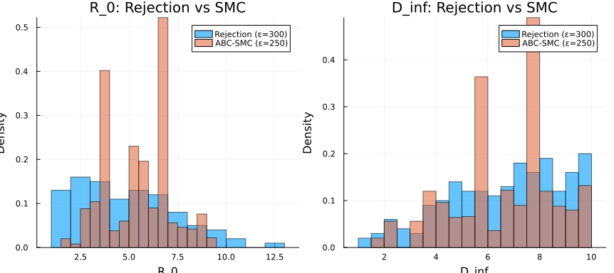

```julia
# Visual comparison
p1 = histogram(abc_df.R_0, bins=20, alpha=0.6, normalize=:pdf,
               label="Rejection (ε=300)", xlabel="R_0", ylabel="Density")
histogram!(p1, abc_smc_df.R_0, bins=20, alpha=0.6, normalize=:pdf,
           label="ABC-SMC (ε=250)")

p2 = histogram(abc_df.D_inf, bins=20, alpha=0.6, normalize=:pdf,
               label="Rejection (ε=300)", xlabel="D_inf", ylabel="Density")
histogram!(p2, abc_smc_df.D_inf, bins=20, alpha=0.6, normalize=:pdf,
           label="ABC-SMC (ε=250)")

plot(p1, p2, layout=(1, 2), size=(900, 400),
     title=["R_0: Rejection vs SMC" "D_inf: Rejection vs SMC"])
```

Compare the printed counts rather than taking any efficiency claim on trust, including this session’s.

The generations usually get *more* expensive, not less: the first is cheap because a loose threshold accepts almost anything, and each tightening tends to cost more simulations per particle than the last. Now and then a later generation comes out cheaper, so read the direction rather than the individual numbers.

Whether the total beats rejection sampling depends on the schedule, and on a problem this small it does not. The two totals printed above are not comparable as they stand, though: the rejection run stops at a threshold of 300 and ABC-SMC goes on to 250, so one has bought a tighter posterior than the other. Compare them at the same final threshold, and per effective sample rather than per draw. Rejection sampling’s draws are unweighted, so its effective sample size is the number of draws; run to 250 it needs about 2300 simulations for 200 of them, which is about 11 each. ABC-SMC’s 100 particles are weighted, so the figure to divide by is the effective sample size printed for its final generation, which is well below 100. Its whole total counts, because the earlier generations cannot be skipped: 831 simulations against a final effective sample size of 18.5 is about 45 each. So rejection is roughly four times cheaper on this run. That gap is not stable, though. The effective sample size of the last generation swings widely between runs, and across repeated runs the median comes out nearer 20 per effective sample, which puts rejection about twice ahead rather than four times. A generation whose effective sample size collapses tends to make the next one dearer, because the next generation perturbs from whatever few particles still carry weight. Prior acceptance is about a quarter at a threshold of 300 and still around 9% at 250, so rejection can reach the tighter threshold directly. ABC-SMC concentrates its effort where the data are, without being told where that is, and that pays on problems whose prior acceptance is orders of magnitude lower than this one.

Watch the effective sample size as well. The first generation has all 100 particles, because they are drawn from the prior and weighted equally. After that it drops sharply, often to a small fraction of the particle count, and how far varies a great deal between runs: repeat this with different seeds and generation 2 can land anywhere from single figures to about half the particles. What does not vary is the direction.

That is weight degeneracy. The effective sample size printed for the final generation, against the 100 particles it is computed from, is the measure of it, and the density plot above is drawn from correspondingly fewer distinct parameter vectors than its 1000 draws suggest, and its apparent concentration is partly an artefact of duplication rather than evidence of a sharper posterior. Production implementations resample between generations and adapt the kernel width to control this; ours does neither, so read the final spread as indicative rather than as a posterior you would report.

**ImportantAssessing ABC posterior quality**

Rejection ABC does not produce chains, so chain diagnostics like R-hat have nothing to work with. ABC-SMC does carry weights, and the effective sample size of those weights is worth watching, as above. Beyond that, assess ABC posterior quality by:

- **Acceptance rate**: Very low rates (< 0.1%) suggest the threshold is too strict or the model is a poor fit. Very high rates (> 10%) suggest the threshold is too loose and the posterior is close to the prior.
- **Visual comparison with likelihood-based posteriors**: When a likelihood is available (as in this session), run both methods and compare. Large discrepancies suggest either the ABC threshold is too loose or the distance metric captures different features than the likelihood.
- **Threshold sensitivity**: Run ABC with several thresholds. If the posterior changes substantially as you tighten the threshold, it has not yet converged — you need a stricter threshold (and more computation).
- **Coverage of prior**: If the ABC posterior looks very similar to the prior, the threshold is too loose and the data are not informing the inference.
- **Replicate runs**: Run ABC multiple times with different random seeds. If posteriors differ substantially between runs, you need more particles or a less strict threshold.

# The big picture: Likelihood vs ABC

Now let’s step back and compare all our approaches - parametric likelihoods and ABC methods - to see what’s fundamentally different (and what’s surprisingly similar).

## Summary of approaches

| Approach | What you specify | What’s arbitrary | Computational cost |
| --- | --- | --- | --- |
| **Poisson likelihood** | Parametric distribution | Why Poisson? | Fast (MCMC) |
| **NegBin likelihood** | Parametric + overdispersion | Why NegBin? | Fast (MCMC) |
| **ABC (L1)** | Distance metric | Why L1? | Slow (many simulations) |
| **ABC (weighted)** | Distance + weights | Why these weights? | Slow (many simulations) |

## Do they give similar results?

Comparing the posteriors:

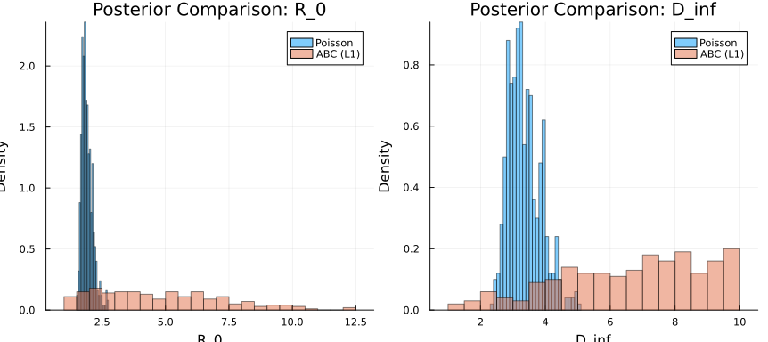

```julia
# Extract MCMC results
mcmc_df = DataFrame(chain_poisson)

# Plot comparison
p1 = histogram(mcmc_df.R_0, bins=30, alpha=0.5,
               label="Poisson", normalize=:pdf)
histogram!(p1, abc_df.R_0, bins=30, alpha=0.5,
           label="ABC (L1)", normalize=:pdf,
           xlabel="R_0", ylabel="Density",
           title="Posterior Comparison: R_0")

p2 = histogram(mcmc_df.D_inf, bins=30, alpha=0.5,
               label="Poisson", normalize=:pdf)
histogram!(p2, abc_df.D_inf, bins=30, alpha=0.5,
           label="ABC (L1)", normalize=:pdf,
           xlabel="D_inf", ylabel="Density",
           title="Posterior Comparison: D_inf")

plot(p1, p2, layout=(1, 2), size=(900, 400))
```

**How to interpret these plots**: Look for whether the posterior distributions overlap substantially. If the MCMC (Poisson) and ABC (L1) posteriors cover a similar range and peak in similar places, the two approaches agree — meaning the choice of observation model has little effect on inference for this dataset. If one posterior is much wider, shifted, or multimodal compared to the other, the observation model is influencing conclusions. A useful rule of thumb: if the posterior means are within one standard deviation of each other and the bulk of the distributions overlap, the methods are giving consistent answers.

**Discussion**: Are the posteriors similar or different? What does this tell us about the observation model choice?

# When does it matter?

## Sensitivity analysis

The choice between Poisson, NegBin, and ABC matters most when:

1. *Outliers*: Extreme observations far from predictions
2. *Tail behaviour*: Rare events (very low or very high counts)
3. *Overdispersion*: Systematic variance > mean in data
4. *Model misspecification*: When the mechanistic model is wrong

We can test sensitivity to outliers:

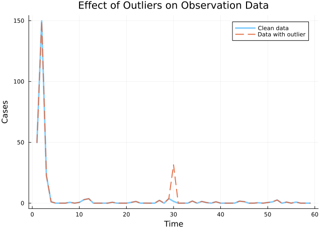

```julia
# Helper function to simulate and return incidence
function simulate_and_summarize(params)
    R_0, D_inf, ρ = params
    θ = Dict(:R_0 => R_0, :D_inf => D_inf)
    traj = simulate_sir(θ, init_test, times)
    return ρ .* traj.Inc[2:end]  ## drop the padding zero at t = 0, to match the observations
end

# Create one synthetic dataset, then a copy of it with a single day disturbed.
# Drawing fresh noise for each would make the two datasets differ everywhere, and
# the comparison below would measure the noise rather than the outlier.
function synthetic_data()
    true_params = [10.0, 2.5, 0.8]
    true_data = simulate_and_summarize(true_params)
    noisy_data = true_data .+ randn(length(true_data)) .* 2.0
    return max.(noisy_data, 0.0)  # No negative cases
end

data_clean = synthetic_data()
data_outlier = copy(data_clean)
data_outlier[30] += 30.0  # Artificial spike on a single day

# Plot
# The two series differ at one day only, so draw the second dashed or it hides
# the first completely
plot(flu_tdc.time, data_clean, label="Clean data", linewidth=3, alpha=0.5)
plot!(flu_tdc.time, data_outlier, label="Data with outlier", linewidth=2, linestyle=:dash,
      xlabel="Time", ylabel="Cases",
      title="Effect of Outliers on Observation Data")
```

**TipExercise: How much does one bad day matter?**

Compare how the Poisson likelihood and ABC with L1 distance respond to the outlier.

Simulate from a few parameter sets, compute the Poisson log-likelihood and the L1 distance against both `data_clean` and `data_outlier`, and see which metric shifts more. If you have time, try a full fit with both and compare the posteriors.

**TipHint: Outlier robustness**

Poisson likelihood is sensitive to outliers because the log-probability drops sharply for counts far from the mean. An outlier of +30 cases when the model predicts 5 contributes a large penalty to the log-likelihood, pulling parameter estimates towards values that accommodate the outlier.

ABC with L1 distance (defined earlier as `sum(abs.(sim .- obs))`) is more robust because the penalty grows linearly with the discrepancy, not exponentially. A single outlier affects the total distance, but doesn’t dominate as severely.

**NoteSolution**

```julia
# Compare how each metric responds to the outlier
true_params = [10.0, 2.5, 0.8]
predicted = simulate_and_summarize(true_params)

# Poisson log-likelihood
function poisson_loglik(predicted, observed)
    ll = 0.0
    for i in eachindex(observed)
        λ = max(predicted[i], 1e-10)
        ll += logpdf(Poisson(λ), round(Int, observed[i]))
    end
    return ll
end

println("Poisson log-likelihood:")
println("  Clean data:   ", round(poisson_loglik(predicted, data_clean), digits=2))
println("  Outlier data: ", round(poisson_loglik(predicted, data_outlier), digits=2))

println("\nL1 distance:")
println("  Clean data:   ", round(distance_L1(predicted, data_clean), digits=2))
println("  Outlier data: ", round(distance_L1(predicted, data_outlier), digits=2))

# The Poisson log-likelihood drops much more dramatically with the outlier,
# because a count of ~35 when expecting ~5 has near-zero Poisson probability.
# The L1 distance increases by only ~30 (the size of the outlier).
```

[output not shown]

# The philosophical question

## Is there a “correct” observation model?

**No!** There are only:

1. **More or less mechanistically motivated** choices
   - E.g., modelling test sensitivity explicitly vs using NegBin
2. **More or less flexible** choices
   - Poisson (rigid) → NegBin (flexible) → ABC (very flexible)
3. **More or less computationally convenient** choices
   - MCMC with parametric likelihood (fast)
   - ABC (slow but general)

## Practical advice

**When to use parametric likelihoods (Poisson/NegBin)**:

- You have a tractable likelihood function
- You want efficient inference (MCMC with gradients)
- The parametric family is flexible enough
- You’re comfortable with the implicit distance metric

**When to use ABC/likelihood-free**:

- Likelihood is truly intractable (stochastic models, agent-based models)
- You want to make your distance metric explicit
- You care more about specific summary statistics than full data
- You want robustness to model misspecification

**Best practice**:

- Try multiple observation models (Poisson, NegBin, ABC with different distances)
- Check if scientific conclusions change
- If they don’t → observation model choice doesn’t matter much
- If they do → you’ve learned something about what features of the data drive inference!

# Learning points

**TipLearning points**

- ABC replaces the likelihood with an explicit distance, but choosing L1 over L2 over a weighted distance is the same kind of choice as picking Poisson over negative binomial
- The acceptance threshold is the hard part: too tight and nothing is accepted, too loose and you are sampling the prior
- ABC-SMC walks the threshold down in stages, concentrating effort where the data are without being told where that is, at the cost of weights that can become very uneven. On a problem as small as this one, where the prior already accepts often, it does not pay for itself
- Likelihoods are fast and need a tractable model; ABC is slow and needs only a simulator
- A single outlying observation moves a Poisson likelihood far more than an L1 distance, which is the clearest sign the two are different distance functions

# Going further

## Summary statistics for ABC

Instead of comparing full time series, ABC often works better with carefully chosen summary statistics. For epidemic data, useful summaries include:

- **Total cases**: Sum of all observations
- **Peak timing**: Day with maximum incidence
- **Peak height**: Maximum daily incidence
- **Growth rate**: Initial doubling time or exponential growth rate
- **Final size**: Cumulative attack rate

Here is an example of how to define and use summary statistics for ABC:

```julia
"""Extract summary statistics from an epidemic time series."""
function epidemic_summaries(data)
    return [
        sum(data),                          # Total cases
        argmax(data),                       # Peak timing (day index)
        maximum(data),                      # Peak height
        sum(data[1:min(5, length(data))])   # Early cumulative cases (proxy for growth rate)
    ]
end

# Distance on summaries rather than full time series
function distance_summaries(sim, obs)
    s_sim = epidemic_summaries(sim)
    s_obs = epidemic_summaries(obs)
    # Normalise each summary by the observed value to make them comparable
    return sum(abs.(s_sim .- s_obs) ./ (abs.(s_obs) .+ 1.0))
end
```

Using fewer, well-chosen summaries can make ABC more robust to noise and model misspecification. However, there is a trade-off: summaries that discard too much information will produce wider posteriors. The choice of which summaries to use is problem-specific and often requires experimentation.

Try passing `distance_summaries` to `abc_rejection` in place of `distance_L1` and compare the posteriors you get. The four summaries throw away the day-to-day shape of the curve, so expect them to widen. How much each parameter widens tells you how much of what identified it was in the detail of the trajectory rather than in its peak, total and timing.

## Alternative observation models

The choice of observation model affects inference more than many researchers realise. Consider exploring:

- **Gaussian likelihood**: Appropriate when counts are large and approximately symmetric
- **Zero-inflated models**: When surveillance systems miss entire days
- **Reporting delay models**: When cases are reported with variable lag

Computing the variance/mean ratio in your data can help diagnose whether Poisson (ratio ≈ 1) or Negative Binomial (ratio > 1) is more appropriate.

## Robust distance metrics

For ABC with outliers or model misspecification, consider robust distances:

- **Median absolute deviation** instead of mean squared error
- **Quantile-based distances** that down-weight extreme values
- **Feature-based distances** that focus on epidemiologically meaningful patterns

Try replacing `distance_L1` in `abc_rejection` with a median-based version, `distance_median(sim, obs) = median(abs.(sim .- obs))`, and compare the posteriors. A robust distance stops a handful of large daily discrepancies dominating the fit, so how much the posterior moves tells you how much of it was being decided by a few days.

# References

- Toni, T. et al. (2009). [Approximate Bayesian computation scheme for parameter inference and model selection in dynamical systems](https://doi.org/10.1098/rsif.2008.0172). *J. R. Soc. Interface* 6(31), 187-202. (The ABC-SMC paper - highly readable introduction)
- Wood, S.N. (2010). [Statistical inference for noisy nonlinear ecological dynamic systems](https://doi.org/10.1038/nature09319). *Nature* 466, 1102-1104. (Synthetic likelihood approach)
- Marin, J.-M. et al. (2012). [Approximate Bayesian computational methods](https://doi.org/10.1007/s11222-011-9288-2). *Statistics and Computing* 22, 1167-1180.
- Cranmer, K. et al. (2020). [The frontier of simulation-based inference](https://doi.org/10.1073/pnas.1912789117). *PNAS* 117(48), 30055-30062. (Comprehensive review of modern likelihood-free methods)

# Next session

You have now met every family of method the course covers. Choosing an inference approach puts them side by side, asks which one your own problem needs, and points at the optional sessions that go further.